# Predicting Life Expectancy

STAT 420 Final Data Analysis Project

# Introduction

Life expectancy varies greatly across the world. Understanding the factors that influence life expectancy can provide insights for policymakers, healthcare providers, and individuals. This project aims to delve into the determinants of life expectancy.

The dataset used is from the World Health Organization (WHO) and United Nations, which provides a wealth of data related to life expectancy across 193 countries. The dataset, publicly available on Kaggle under the title “Life Expectancy (WHO)”, comprises 22 columns and 2,938 observations. Each observation represents the state of a given country in a particular year, with 20 predictor variables providing comprehensive information about various factors potentially impacting life expectancy.

The predictor variables span across a broad spectrum, including immunization-related factors, mortality factors, economic indicators, and social factors. Among these, we believe certain variables like the status of the country (developed vs developing), infant mortality rate, adult mortality rate, health expenditure, GDP, and average years of schooling may have significant importance in predicting life expectancy.

Our objective in this project is to create a model that can effectively predict life expectancy based on these predictors. We’re particularly interested in this dataset due to our curiosity about the factors influencing life expectancy and our desire to uncover the differences between countries that lead to a wide range of life expectancies. By building this model, we aim to provide insights that could potentially guide health policy and contribute to improvements in global health outcomes.

# Methods

### Loading Data

```r
#read data
library(readr)
life_expectancy_data_full = read_csv("Life Expectancy Data.csv")
```

We will remove rows with empty values to make analysis easier.

```r
#remove rows with empty vals
life_expectancy_data = na.omit(life_expectancy_data_full)
#View(life_expectancy_data)
```

For our analysis, we have chosen to convert the predictors Status and Country into factor variables, so that we can treat them as categories.

```r
#convert Status (levels: Developing, Developed) to factor variable
life_expectancy_data$Status = as.factor(life_expectancy_data$Status)

#convert Country to factor variable
life_expectancy_data$Country = as.factor(life_expectancy_data$Country)
```

### Exploratory Analysis

The pairs plot of all of the variables was very large, so we will display correlations between the numeric variables in the dataset with a Correlogram instead.

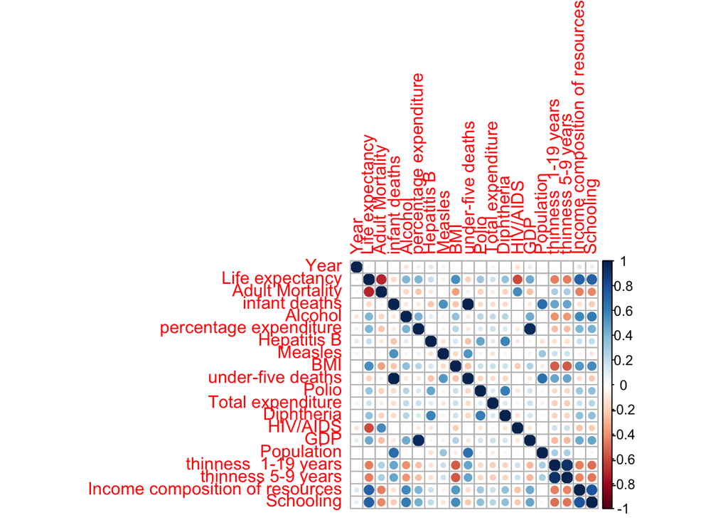

```r
#pairs(life_expectancy_data)

#find pairwise correlations between all numeric variables in dataset
numeric_cols =  unlist(lapply(life_expectancy_data, is.numeric))
life_expectancy_data_numeric = life_expectancy_data[ , numeric_cols]
#View(life_expectancy_data_numeric)

correlations = cor(life_expectancy_data_numeric)

#plot correlogram (positive correlations are blue, negative correlations are red)
library(corrplot)

corrplot(correlations)
```

We notice that there are a few variables with very high correlations, so we will attempt to address this issue in our modeling.

### Initial Additive Model

First, we create a main effects model using all of the available predictors in the dataset to predict life expectancy.

```r
additive_model = lm(`Life expectancy` ~ ., data = life_expectancy_data)
#summary(additive_model)
```

### Analyze Model

```r
#Calculate LOOCV RMSE
calc_loocv_rmse = function(model) {
  sqrt(mean((resid(model) / (1 - hatvalues(model))) ^ 2))
}

# Function to calculate model metrics

calc_model_metrics = function(model) {
  # Calculate adjusted R squared
  model_adjr2 = summary(model)$adj.r.squared

  # Calculate RMSE
  model_rmse = sqrt(mean(resid(model) ^ 2))

  # Calculate LOOCV RMSE
  model_loocv_rmse = sqrt(mean((resid(model) / (1 - hatvalues(model))) ^ 2))

  # Calculate AIC
  model_AIC = extractAIC(model)[2] # get only the AIC value, not the degrees of freedom

  # Return a list containing the calculated metrics
  list(Adj_R_Squared = model_adjr2, RMSE = model_rmse, LOOCV_RMSE = model_loocv_rmse, AIC = model_AIC)
}

additive_model_metrics = as.data.frame(calc_model_metrics(additive_model))

library(knitr)
knitr::kable(additive_model_metrics, caption = "Additive Model Summary", digits = 4)
```

Additive Model Summary

| Adj_R_Squared | RMSE | LOOCV_RMSE | AIC |
| --- | --- | --- | --- |
| 0.9642 | 1.5859 | 1.7559 | 1824.977 |

### Check model assumptions

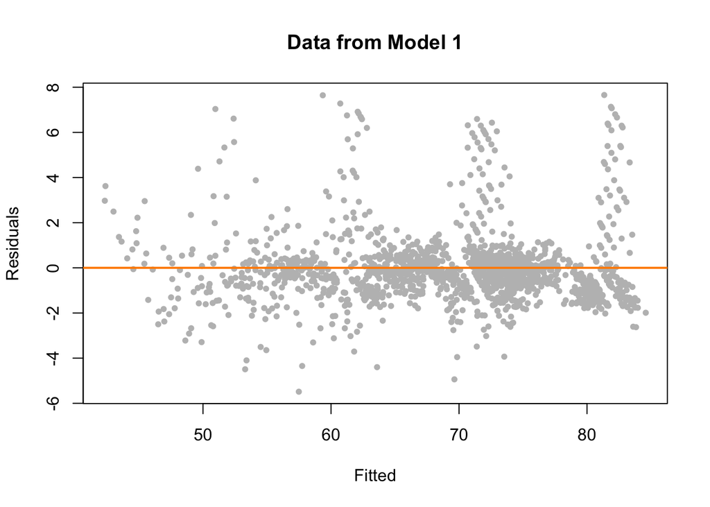

```r
#Fitted vs Residuals Plot

plot(fitted(additive_model), resid(additive_model), col = "grey", pch = 20,
     xlab = "Fitted", ylab = "Residuals", main = "Data from Model 1")
abline(h = 0, col = "darkorange", lwd = 2)
```

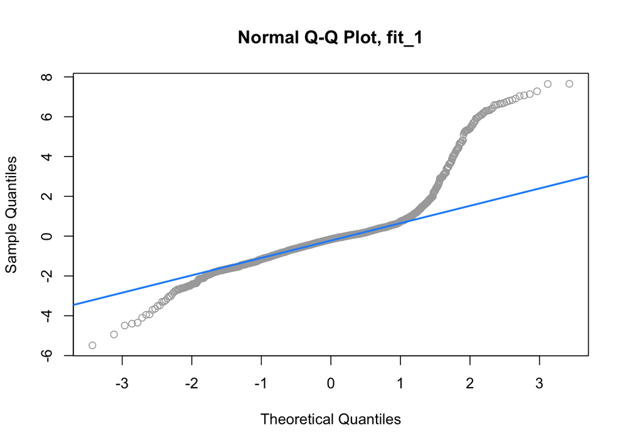

```r
#Q-Q Plot

qqnorm(resid(additive_model), main = "Normal Q-Q Plot, fit_1", col = "darkgrey")
qqline(resid(additive_model), col = "dodgerblue", lwd = 2)
```

The fitted vs residuals plot and Q-Q plot suggest issues with this model’s assumptions, which we will confirm via more formal tests.

```r
library(lmtest)
bptest(additive_model)
```

```
##
##  studentized Breusch-Pagan test
##
## data:  additive_model
## BP = 283.35, df = 151, p-value = 4.012e-10
```

```r
shapiro.test(resid(additive_model))
```

```
##
##  Shapiro-Wilk normality test
##
## data:  resid(additive_model)
## W = 0.82427, p-value < 2.2e-16
```

The results of the Breusch-Pagan test and the Shapiro-Wilk test confirm that this model violates both the constant variance assumption and the normality assumption. We will attempt to improve these issues below.

### Model Improvement: Removing Highly Correlated Variables

We will attempt to fix these issues by removing highly correlated predictors. In particular, the variables `thinness 1-19 years` and `thinness 5-9 years` had a correlation of 0.997. In addition, the variables `under 5 death` and `infant death` had a correlation of 0.928. We’ll remove one from each of the above pairs of predictors and reassess the model.

```r
# Removing infant deaths and thinness 1-19 years
corr_removed_data_1 = life_expectancy_data[ , !(names(life_expectancy_data) %in% c('infant deaths', 'thinness 1-19 years'))]
corr_removed_model_1 = lm(`Life expectancy` ~ ., data = corr_removed_data_1)
corr_removed_metrics_1 = calc_model_metrics(corr_removed_model_1)


# Removing infant deaths and thinness 5-9 years
corr_removed_data_2 = life_expectancy_data[ , !(names(life_expectancy_data) %in% c('infant deaths', 'thinness 5-9 years'))]
corr_removed_model_2 = lm(`Life expectancy` ~ ., data = corr_removed_data_2)
corr_removed_metrics_2 = calc_model_metrics(corr_removed_model_2)


# Removing under 5 deaths and thinness 1-19 years
corr_removed_data_3 = life_expectancy_data[ , !(names(life_expectancy_data) %in% c('under 5 death', 'thinness 1-19 years'))]
corr_removed_model_3 = lm(`Life expectancy` ~ ., data = corr_removed_data_3)
corr_removed_metrics_3 = calc_model_metrics(corr_removed_model_3)

# Removing under 5 deaths and thinness 5-9 years
corr_removed_data_4 = life_expectancy_data[ , !(names(life_expectancy_data) %in% c('under 5 death', 'thinness 5-9 years'))]
corr_removed_model_4 = lm(`Life expectancy` ~ ., data = corr_removed_data_4)
corr_removed_metrics_4 = calc_model_metrics(corr_removed_model_4)

# Create a data frame summarizing the model metrics
model_summary = data.frame(
  Variables_Removed = c("infant deaths + thinness 1-19", "infant deaths + thinness 5-9", "under 5 deaths + thinness 1-19", "under 5 deaths + thinness 5-9 years"),
  Adjusted_R_Squared = c(corr_removed_metrics_1$Adj_R_Squared, corr_removed_metrics_2$Adj_R_Squared, corr_removed_metrics_3$Adj_R_Squared, corr_removed_metrics_4$Adj_R_Squared),
  RMSE = c(corr_removed_metrics_1$RMSE, corr_removed_metrics_2$RMSE, corr_removed_metrics_3$RMSE, corr_removed_metrics_4$RMSE),
  LOOCV_RMSE = c(corr_removed_metrics_1$LOOCV_RMSE, corr_removed_metrics_2$LOOCV_RMSE, corr_removed_metrics_3$LOOCV_RMSE, corr_removed_metrics_4$LOOCV_RMSE),
  AIC = c(corr_removed_metrics_1$AIC, corr_removed_metrics_2$AIC, corr_removed_metrics_3$AIC, corr_removed_metrics_4$AIC)
)

library(knitr)
knitr::kable(model_summary, caption = "Removed Correlated Variable Model Summary", digits = 4)
```

Removed Correlated Variable Model Summary

| Variables_Removed | Adjusted_R_Squared | RMSE | LOOCV_RMSE | AIC |
| --- | --- | --- | --- | --- |
| infant deaths + thinness 1-19 | 0.9640 | 1.5914 | 1.7576 | 1834.247 |
| infant deaths + thinness 5-9 | 0.9639 | 1.5937 | 1.7590 | 1837.088 |
| under 5 deaths + thinness 1-19 | 0.9642 | 1.5859 | 1.7559 | 1824.977 |
| under 5 deaths + thinness 5-9 years | 0.9641 | 1.5883 | 1.7572 | 1827.939 |

### Model Improvement: Log Transformation of Predictor Variables

We will attempt to further improve the model by log transforming certain predictor variables (`Population` and `GDP`).

```r
log_transform_1 = lm(`Life expectancy` ~ . + log(Population) + log(GDP), data = life_expectancy_data)
log_transformed_metrics_1 = calc_model_metrics(log_transform_1)

log_transform_2 = lm(`Life expectancy` ~ . + log(GDP), data = life_expectancy_data)
log_transformed_metrics_2 = calc_model_metrics(log_transform_2)

log_transform_3 = lm(`Life expectancy` ~ . + log(Population), data = life_expectancy_data)
log_transformed_metrics_3 = calc_model_metrics(log_transform_3)


log_model_summary = data.frame(
  Variables_Log_Transformed = c("Population + GDP", "GDP", "Population"),
  Adjusted_R_Squared = c(log_transformed_metrics_1$Adj_R_Squared, log_transformed_metrics_2$Adj_R_Squared, log_transformed_metrics_3$Adj_R_Squared),
  RMSE = c(log_transformed_metrics_1$RMSE, log_transformed_metrics_2$RMSE, log_transformed_metrics_3$RMSE),
  LOOCV_RMSE = c(log_transformed_metrics_1$LOOCV_RMSE, log_transformed_metrics_2$LOOCV_RMSE, log_transformed_metrics_3$LOOCV_RMSE),
  AIC = c(log_transformed_metrics_1$AIC, log_transformed_metrics_2$AIC, log_transformed_metrics_3$AIC)
)

knitr::kable(log_model_summary, caption = "Log Transformation Model Summary", digits = 4)
```

Log Transformation Model Summary

| Variables_Log_Transformed | Adjusted_R_Squared | RMSE | LOOCV_RMSE | AIC |
| --- | --- | --- | --- | --- |
| Population + GDP | 0.9642 | 1.5853 | 1.7583 | 1827.612 |
| GDP | 0.9642 | 1.5853 | 1.7569 | 1825.613 |
| Population | 0.9642 | 1.5859 | 1.7574 | 1826.977 |

The resulting AIC for this model is still rather large, so we will use AIC and BIC backwards search to attempt to further improve the model.

### Model Improvement: Quality Criterion & Backwards Search Procedure

First, we consider both AIC and BIC on the initial additive model containing all predictor variables.

```r
n = length(resid(additive_model))

#AIC and BIC for additive models
additive_mod_back_aic = step(additive_model, direction = "backward", trace = 0)
additive_mod_back_bic = step(additive_model, direction = "backward", k = log(n), trace = 0)

metrics_additive_mod_back_aic = calc_model_metrics(additive_mod_back_aic)
metrics_additive_mod_back_bic = calc_model_metrics(additive_mod_back_bic)
```

```r
additive_model_summary = data.frame(
  Criterion = c("additive AIC", "Additive BIC"),

  Adjusted_R_Squared =
  c(metrics_additive_mod_back_aic$Adj_R_Squared, metrics_additive_mod_back_bic$Adj_R_Squared),

  RMSE = c(metrics_additive_mod_back_aic$RMSE, metrics_additive_mod_back_bic$RMSE),

  LOOCV_RMSE =
    c(metrics_additive_mod_back_aic$LOOCV_RMSE, metrics_additive_mod_back_bic$LOOCV_RMSE),

  AIC = c(metrics_additive_mod_back_aic$AIC, metrics_additive_mod_back_bic$AIC)

)

knitr::kable(additive_model_summary, caption = "Additive model AIC and BIC Summary", digits = 4)
```

Additive model AIC and BIC Summary

| Criterion | Adjusted_R_Squared | RMSE | LOOCV_RMSE | AIC |
| --- | --- | --- | --- | --- |
| additive AIC | 0.9643 | 1.5882 | 1.7430 | 1809.740 |
| Additive BIC | 0.9642 | 1.5932 | 1.7455 | 1814.022 |

We see that using AIC and a backwards search on the additive model resulted in a significant improvement in AIC, with an AIC of 1809.740.

Next, we consider using AIC and BIC on the models with highly correlated variables removed.

```r
# AIC and BIC for models without highly corelated features
corr_mod_1_back_aic = step(corr_removed_model_1, direction = "backward", trace = 0)
corr_mod_2_back_aic = step(corr_removed_model_2, direction = "backward", trace = 0)
corr_mod_3_back_aic = step(corr_removed_model_3, direction = "backward", trace = 0)

corr_mod_1_back_bic = step(corr_removed_model_1, direction = "backward", k = log(n), trace = 0)
corr_mod_2_back_bic = step(corr_removed_model_2, direction = "backward", k = log(n), trace = 0)
corr_mod_3_back_bic = step(corr_removed_model_3, direction = "backward", k = log(n), trace = 0)

metrics_corr_mod_1_back_aic = calc_model_metrics(corr_mod_1_back_aic)
metrics_corr_mod_2_back_aic = calc_model_metrics(corr_mod_2_back_aic)
metrics_corr_mod_3_back_aic = calc_model_metrics(corr_mod_3_back_aic)

metrics_corr_mod_1_back_bic = calc_model_metrics(corr_mod_1_back_bic)
metrics_corr_mod_2_back_bic = calc_model_metrics(corr_mod_2_back_bic)
metrics_corr_mod_3_back_bic = calc_model_metrics(corr_mod_3_back_bic)
```

```r
corr_model_summary = data.frame(
  Criterion = c("corr AIC model 1", "corr AIC model 2", "corr AIC model 3",
                               "corr BIC model 1","corr BIC model 2", "corr BIC model 3" ),

  Adjusted_R_Squared =
  c(metrics_corr_mod_1_back_aic$Adj_R_Squared, metrics_corr_mod_2_back_aic$Adj_R_Squared,
    metrics_corr_mod_3_back_aic$Adj_R_Squared,
    metrics_corr_mod_1_back_bic$Adj_R_Squared, metrics_corr_mod_2_back_bic$Adj_R_Squared,
    metrics_corr_mod_3_back_bic$Adj_R_Squared
    ),

  RMSE =
      c(metrics_corr_mod_1_back_aic$RMSE, metrics_corr_mod_2_back_aic$RMSE,
    metrics_corr_mod_3_back_aic$RMSE,
    metrics_corr_mod_1_back_bic$RMSE, metrics_corr_mod_2_back_bic$RMSE,
    metrics_corr_mod_3_back_bic$RMSE
    ),
  LOOCV_RMSE =
    c(metrics_corr_mod_1_back_aic$LOOCV_RMSE, metrics_corr_mod_2_back_aic$LOOCV_RMSE,
    metrics_corr_mod_3_back_aic$LOOCV_RMSE,
    metrics_corr_mod_1_back_bic$LOOCV_RMSE, metrics_corr_mod_2_back_bic$LOOCV_RMSE,
    metrics_corr_mod_3_back_bic$LOOCV_RMSE
    ),

  AIC = c(metrics_corr_mod_1_back_aic$AIC, metrics_corr_mod_2_back_aic$AIC,
    metrics_corr_mod_3_back_aic$AIC,
    metrics_corr_mod_1_back_bic$AIC, metrics_corr_mod_2_back_bic$AIC,
    metrics_corr_mod_3_back_bic$AIC
    )
)

knitr::kable(corr_model_summary, caption = "correlations removed model AIC and BIC Summary", digits = 4)
```

correlations removed model AIC and BIC Summary

| Criterion | Adjusted_R_Squared | RMSE | LOOCV_RMSE | AIC |
| --- | --- | --- | --- | --- |
| corr AIC model 1 | 0.9641 | 1.5935 | 1.7457 | 1818.552 |
| corr AIC model 2 | 0.9640 | 1.5958 | 1.7484 | 1823.343 |
| corr AIC model 3 | 0.9643 | 1.5882 | 1.7430 | 1809.740 |
| corr BIC model 1 | 0.9639 | 1.6003 | 1.7497 | 1824.704 |
| corr BIC model 2 | 0.9638 | 1.6043 | 1.7531 | 1830.836 |
| corr BIC model 3 | 0.9642 | 1.5932 | 1.7455 | 1814.022 |

The results show that using AIC and BIC on the additive model with highly correlated variables removed results in varying improvement in AIC.

We will investigate the effect of using these quality criteria and search procedures on the models with log transformations of certain predictors.

```r
# AIC and BIC for models with log transformations
tranform_mod_1_back_aic = step(log_transform_1, direction = "backward", trace = 0)
tranform_mod_2_back_aic = step(log_transform_2, direction = "backward", trace = 0)
tranform_mod_3_back_aic = step(log_transform_3, direction = "backward", trace = 0)

tranform_mod_1_back_bic = step(log_transform_1, direction = "backward", k = log(n), trace = 0)
tranform_mod_2_back_bic = step(log_transform_2, direction = "backward", k = log(n), trace = 0)
tranform_mod_3_back_bic = step(log_transform_3, direction = "backward", k = log(n), trace = 0)

metrics_tranform_mod_1_back_aic = calc_model_metrics(tranform_mod_1_back_aic)
metrics_tranform_mod_2_back_aic = calc_model_metrics(tranform_mod_2_back_aic)
metrics_tranform_mod_3_back_aic = calc_model_metrics(tranform_mod_3_back_aic)


metrics_tranform_mod_1_back_bic = calc_model_metrics(tranform_mod_1_back_bic)
metrics_tranform_mod_2_back_bic = calc_model_metrics(tranform_mod_2_back_bic)
metrics_tranform_mod_3_back_bic = calc_model_metrics(tranform_mod_3_back_bic)
```

```r
transform_model_summary = data.frame(
  Variables_Log_Transformed = c("Log transform AIC model 1", "Log transform AIC model 2", "Log transform AIC model 3",
                               "Log transform BIC model 1","Log transformBIC model 2", "Log transform BIC model 3" ),

  Adjusted_R_Squared =
  c(metrics_tranform_mod_1_back_aic$Adj_R_Squared, metrics_tranform_mod_2_back_aic$Adj_R_Squared, metrics_tranform_mod_3_back_aic$Adj_R_Squared,

    metrics_tranform_mod_1_back_bic$Adj_R_Squared, metrics_tranform_mod_2_back_bic$Adj_R_Squared, metrics_tranform_mod_3_back_bic$Adj_R_Squared
    ),

  RMSE =
      c(metrics_tranform_mod_1_back_aic$RMSE, metrics_tranform_mod_2_back_aic$RMSE,
    metrics_tranform_mod_3_back_aic$RMSE,
    metrics_tranform_mod_1_back_bic$RMSE, metrics_tranform_mod_2_back_bic$RMSE,
    metrics_tranform_mod_3_back_bic$RMSE
    ),
  LOOCV_RMSE =
    c(metrics_tranform_mod_1_back_aic$LOOCV_RMSE, metrics_tranform_mod_2_back_aic$LOOCV_RMSE,
    metrics_tranform_mod_3_back_aic$LOOCV_RMSE,
    metrics_tranform_mod_1_back_bic$LOOCV_RMSE, metrics_tranform_mod_2_back_bic$LOOCV_RMSE,
    metrics_tranform_mod_3_back_bic$LOOCV_RMSE
    ),

  AIC = c(metrics_tranform_mod_1_back_aic$AIC, metrics_tranform_mod_2_back_aic$AIC,
    metrics_tranform_mod_3_back_aic$AIC,
    metrics_tranform_mod_1_back_bic$AIC, metrics_tranform_mod_2_back_bic$AIC,
    metrics_tranform_mod_3_back_bic$AIC
    )
)

knitr::kable(transform_model_summary, caption = "log transformation model AIC and BIC Summary", digits = 4)
```

log transformation model AIC and BIC Summary

| Variables_Log_Transformed | Adjusted_R_Squared | RMSE | LOOCV_RMSE | AIC |
| --- | --- | --- | --- | --- |
| Log transform AIC model 1 | 0.9643 | 1.5882 | 1.7430 | 1809.740 |
| Log transform AIC model 2 | 0.9643 | 1.5882 | 1.7430 | 1809.740 |
| Log transform AIC model 3 | 0.9643 | 1.5882 | 1.7430 | 1809.740 |
| Log transform BIC model 1 | 0.9642 | 1.5932 | 1.7455 | 1814.022 |
| Log transformBIC model 2 | 0.9642 | 1.5932 | 1.7455 | 1814.022 |
| Log transform BIC model 3 | 0.9642 | 1.5932 | 1.7455 | 1814.022 |

Interestingly, we see that using AIC and backwards search on each of the models with log transformations of the predictors resulted in an improved AIC of 1809.74. This was the maximum improvement observed during our analysis.

# Results

```r
corr_model3_summary = data.frame(
  Criterion = c("corr AIC model 3"),
  Adjusted_R_Squared = c(metrics_corr_mod_3_back_aic$Adj_R_Squared),
  RMSE = c(metrics_corr_mod_3_back_aic$RMSE),
  LOOCV_RMSE = c(metrics_corr_mod_3_back_aic$LOOCV_RMSE),
  AIC = c(metrics_corr_mod_3_back_aic$AIC)
)

knitr::kable(corr_model3_summary, caption = "correlations removed model AIC and BIC Summary", digits = 4)
```

correlations removed model AIC and BIC Summary

| Criterion | Adjusted_R_Squared | RMSE | LOOCV_RMSE | AIC |
| --- | --- | --- | --- | --- |
| corr AIC model 3 | 0.9643 | 1.5882 | 1.743 | 1809.74 |

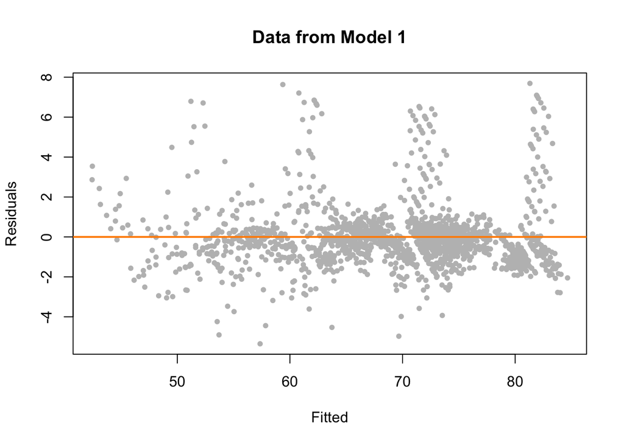

```r
#Fitted vs Residuals Plot

plot(fitted(corr_mod_3_back_aic), resid(corr_mod_3_back_aic), col = "grey", pch = 20,
     xlab = "Fitted", ylab = "Residuals", main = "Data from Model 1")
abline(h = 0, col = "darkorange", lwd = 2)
```

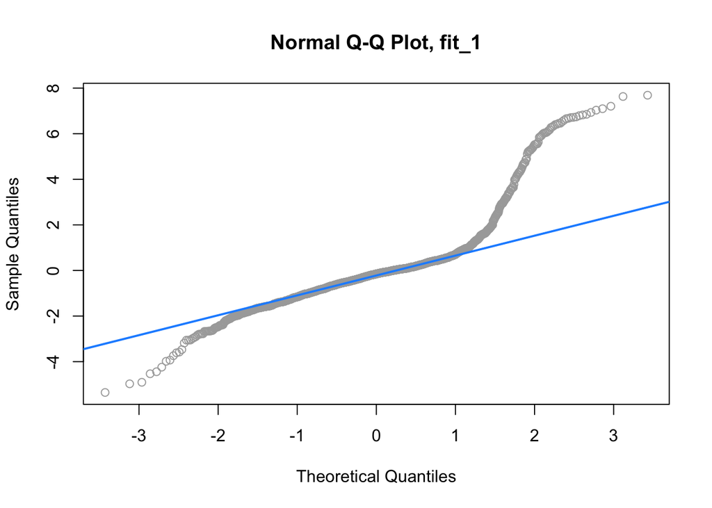

```r
#Q-Q Plot

qqnorm(resid(corr_mod_3_back_aic), main = "Normal Q-Q Plot, fit_1", col = "darkgrey")
qqline(resid(corr_mod_3_back_aic), col = "dodgerblue", lwd = 2)
```

```r
bptest(corr_mod_3_back_aic)
```

```
##
##  studentized Breusch-Pagan test
##
## data:  corr_mod_3_back_aic
## BP = 280.98, df = 141, p-value = 2.419e-11
```

```r
shapiro.test(resid(corr_mod_3_back_aic))
```

```
##
##  Shapiro-Wilk normality test
##
## data:  resid(corr_mod_3_back_aic)
## W = 0.82406, p-value < 2.2e-16
```

```r
anova(corr_mod_3_back_aic, additive_model)
```

```
## Analysis of Variance Table
##
## Model 1: `Life expectancy` ~ Country + Year + `infant deaths` + Alcohol +
##     `Hepatitis B` + `under-five deaths` + `HIV/AIDS` + `thinness 5-9 years` +
##     `Income composition of resources` + Schooling
## Model 2: `Life expectancy` ~ Country + Year + Status + `Adult Mortality` +
##     `infant deaths` + Alcohol + `percentage expenditure` + `Hepatitis B` +
##     Measles + BMI + `under-five deaths` + Polio + `Total expenditure` +
##     Diphtheria + `HIV/AIDS` + GDP + Population + `thinness  1-19 years` +
##     `thinness 5-9 years` + `Income composition of resources` +
##     Schooling
##   Res.Df    RSS Df Sum of Sq     F Pr(>F)
## 1   1507 4159.6
## 2   1497 4147.6 10    11.997 0.433  0.931
```

The results suggest that this model still violates the constant variance and normality assumptions. So, although the predictive power of this model appears strong, we cannot trust the inferences that are made from this model. In spite of this, an ANOVA F-test suggests that this model is preferred over the larger additive model containing all predictors for predicting life expectancy.

Next we will examine our alternative model with the best improvement in AIC: the model created from using AIC and a backwards search on the log transformed model.

```r
tranform_mod_1_back_aic_summary = data.frame(
  Variables_Log_Transformed = c("Log transform AIC model 1"),
  Adjusted_R_Squared = c(metrics_tranform_mod_1_back_aic$Adj_R_Squared),
  RMSE = c(metrics_tranform_mod_1_back_aic$RMSE),
  LOOCV_RMSE = c(metrics_tranform_mod_1_back_aic$LOOCV_RMSE),
  AIC = c(metrics_tranform_mod_1_back_aic$AIC)
)

knitr::kable(tranform_mod_1_back_aic_summary, caption = "log transformation model AIC and BIC Summary", digits = 4)
```

log transformation model AIC and BIC Summary

| Variables_Log_Transformed | Adjusted_R_Squared | RMSE | LOOCV_RMSE | AIC |
| --- | --- | --- | --- | --- |
| Log transform AIC model 1 | 0.9643 | 1.5882 | 1.743 | 1809.74 |

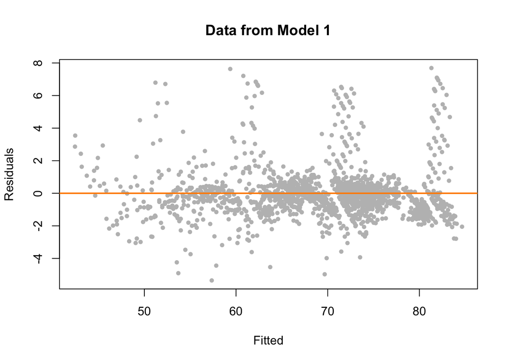

```r
#Fitted vs Residuals Plot

plot(fitted(tranform_mod_1_back_aic), resid(tranform_mod_1_back_aic), col = "grey", pch = 20,
     xlab = "Fitted", ylab = "Residuals", main = "Data from Model 1")
abline(h = 0, col = "darkorange", lwd = 2)
```

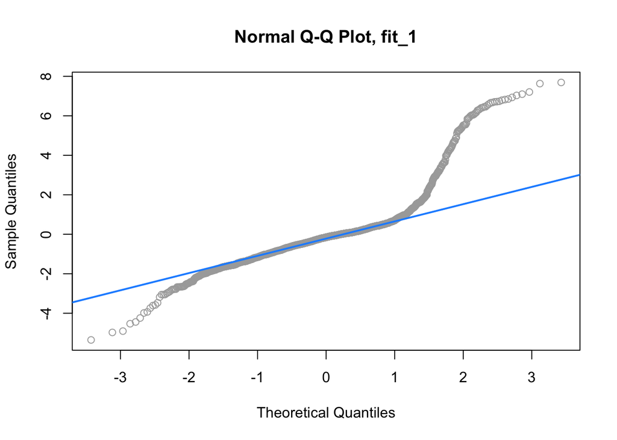

```r
#Q-Q Plot

qqnorm(resid(tranform_mod_1_back_aic), main = "Normal Q-Q Plot, fit_1", col = "darkgrey")
qqline(resid(tranform_mod_1_back_aic), col = "dodgerblue", lwd = 2)
```

```r
bptest(tranform_mod_1_back_aic)
```

```
##
##  studentized Breusch-Pagan test
##
## data:  tranform_mod_1_back_aic
## BP = 280.98, df = 141, p-value = 2.419e-11
```

```r
shapiro.test(resid(tranform_mod_1_back_aic))
```

```
##
##  Shapiro-Wilk normality test
##
## data:  resid(tranform_mod_1_back_aic)
## W = 0.82406, p-value < 2.2e-16
```

The results suggest that, despite the attempts at improvement, this model also violates the constant variance and normality assumptions.

```r
anova(tranform_mod_1_back_aic, additive_model)
```

```
## Analysis of Variance Table
##
## Model 1: `Life expectancy` ~ Country + Year + `infant deaths` + Alcohol +
##     `Hepatitis B` + `under-five deaths` + `HIV/AIDS` + `thinness 5-9 years` +
##     `Income composition of resources` + Schooling
## Model 2: `Life expectancy` ~ Country + Year + Status + `Adult Mortality` +
##     `infant deaths` + Alcohol + `percentage expenditure` + `Hepatitis B` +
##     Measles + BMI + `under-five deaths` + Polio + `Total expenditure` +
##     Diphtheria + `HIV/AIDS` + GDP + Population + `thinness  1-19 years` +
##     `thinness 5-9 years` + `Income composition of resources` +
##     Schooling
##   Res.Df    RSS Df Sum of Sq     F Pr(>F)
## 1   1507 4159.6
## 2   1497 4147.6 10    11.997 0.433  0.931
```

Despite this, comparing this model with the full additive model suggests that we prefer this smaller model for predicting life expectancy.

# Discussions

In this section, we will delve into the implications and interpretation of the results, connecting the Introduction, Methods, and Results to draw meaningful conclusions.

When we picked this data set from the World health organization (WHO), our primary goal was to identify the key predictors that affect the life expectancy of the countries and use these predictors to come up with hypotheses and form models and methods based on these hypotheses and provide meaningful insights based on our discoveries.

A model incorporating all two-way interactions was attempted, but it encountered issues (many NaNs in output), suggesting that this approach may not be suitable for our data set. This information is included in the Appendix for further reference. Future work could involve investigating other modeling approaches or refining the current models to better adhere to the assumptions of linear regression. This could potentially enhance both the prediction accuracy and the inferential capabilities of our models.

In conclusion, our top models likely make acceptable suggestions for predicting life expectancy from predictors within the range of these predictor values. Still, their violation of linear model assumptions prevents us from making probabilistic statements like confidence intervals with these models. In other words, we might get reasonable predictions for the response variable using these models. Still, the estimates of the regression coefficients have increased variance and need to be more beneficial for inference.

# Appendix

```r
additive_model2 = lm(`Life expectancy` ~ . ^ 2, data = life_expectancy_data)
summary(additive_model2)
bptest(additive_model2)
shapiro.test(resid(additive_model2))
```

[output not shown]

Team KWS  
Team Members: Saitejas Mopuri, Kimberly Martin, Woo Jeon